## Functions in R

## Anatomy of a Function

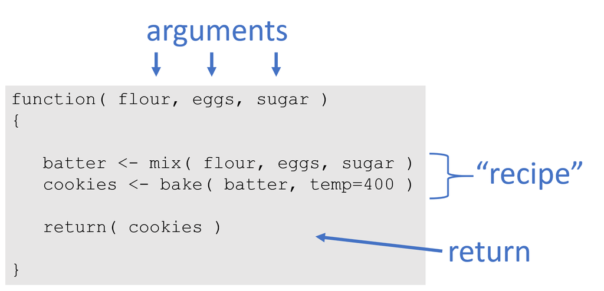

## Example: Mortgage Calculator

```r
### A simple mortgage calculator

   calcMortgage <- function( years, APR, principal )
   {

      months <- years * 12
      int.rate <- APR / 12

      # amortization formula
      monthly.payment <- ( principal * int.rate ) /
                         (1 - (1 + int.rate)^(-months) )

      monthly.payment <- round( monthly.payment, 2 )

      return( monthly.payment )

   }
```

## Use

Calculate monthly payments for a:

- 30-year mortgage
- 5% annual interest rate
- $100,000 loan

```r
calcMortgage( years=30, APR=0.05, principal=100000  )
```

```
## [1] 536.82
```

## Arguments

Note that we need to specify all argument values, or else we get an error:

```r
calcMortgage( APR=0.05, principal=100000  )
```

Error in calcMortgage(APR = 0.05, principal = 1e+05):  
argument “years” is missing, with no default

## Default Arguments

We can specify default values for specific arguments:

```r
### A simple mortgage calculator

   calcMortgage <- function( years=30, APR=0.05, principal )
   {

      months <- years * 12
      int.rate <- APR / 12

      # amortization formula
      monthly.payment <- ( principal * int.rate ) /
                         (1 - (1 + int.rate)^(-months) )

      monthly.payment <- round( monthly.payment, 2 )

      return( monthly.payment )

   }
```

## Default Arguments

Now the previous code that caused an error will run fine:

```r
calcMortgage( principal=100000  )
```

```
## [1] 536.82
```

## Default Arguments

If we do not provide a loan-term, it will assume we want a 30-year mortgage. On the other hand, if we do provide an argument for the loan term, we can override the default.

```r
calcMortgage( principal=100000, years=15 )
```

```
## [1] 790.79
```

## Checking Function Arguments

The args() function is a quick way to peek at arguments for a function. You need to use help(“function_name”) to get more information about what is expected for each argument.

```r
args( plot.default )
```

```
## function (x, y = NULL, type = "p", xlim = NULL, ylim = NULL,
##     log = "", main = NULL, sub = NULL, xlab = NULL, ylab = NULL,
##     ann = par("ann"), axes = TRUE, frame.plot = axes, panel.first = NULL,
##     panel.last = NULL, asp = NA, ...)
## NULL
```

## Assignment

When we call a function in R, the default behavior will be to print the result:

```r
calcMortgage( principal=100000  )
```

```
## [1] 536.82
```

## Assignment

We can instead assign the function output to a new variable:

```r
payments.15.year <- calcMortgage( years=15, principal=100000  )
payments.30.year <- calcMortgage( years=30, principal=100000  )
```

These values are then stored, and can be used later or printed by typing the object name:

```r
payments.15.year
```

```
## [1] 790.79
```

```r
payments.30.year
```

```
## [1] 536.82
```